# STA 2201H Take-Home Exam Solutions

Ameer Dharamshi

April 14, 2020

# Introduction

First, import the data:

```r
airbnb <- read.csv("airbnb.csv")

#Convert price data from character to string
airbnb <- airbnb %>%
  mutate(price = str_remove(price, "\\$"),
         price = str_remove(price, ","),
         price = as.integer(price))
```

## Data integrity checks

Let’s start by performing basic data integrity checks. First, lets check for duplicates.

```r
airbnb %>% count()
```

```
## # A tibble: 1 x 1
##       n
##   <int>
## 1 23397
```

```r
airbnb %>% distinct() %>% count()
```

```
## # A tibble: 1 x 1
##       n
##   <int>
## 1 23186
```

```r
airbnb <- airbnb %>% distinct()
```

There are roughly 200 duplicate rows in the dataset. While it is possible for someone to own two similar properties and list them both, having identical review scores is less plausible. We will remove the duplicates to be safe.

Next, we can search for missing values.

While summary is a little messy (not displayed here), it provides plenty of valuable information for us to digest. First, let’s discuss the missing values. The most striking column is square_feet. Of the 23186, 23043 observations are missing values. Of the actual values, over half of them are set to 0. While the housing market in Toronto is outrageous, 0 square feet is beyond absurd! This is just more missing values. Given that the vast majority of the column is missing, we cannot expect to draw much information from the square footage of a listing. However, we have other columns such as bathrooms, accommodates, and bedrooms that offer similar information. We would expect the true square footage values to be highly correlated with these three columns. Given that they have very few missing values (10, 0, and 25 respectively), this will suffice for providing listing size information. The second set of missing values of interest are those regarding the hosts. Aside from the host_id column, all of the host specific columns are missing exactly 283 values. Note that this excludes the “N/A” entry into the host_response_time column which would appear to represent an actual “N/A” input. Perhaps this is the case where the hosts did not respond at all to guests. Before looking at review scores, let’s confirm whether the 283 NA’s are common between all of the host columns.

```r
airbnb %>%
  select(starts_with("host")) %>%
  select(-host_id) %>%
  filter_all(is.na) %>%
  count()
```

```
## # A tibble: 1 x 1
##       n
##   <int>
## 1   283
```

As we suspected, the 283 NA values are common between host columns. This indicates that there are 283 listings where we know nothing about the hosts other than their host_id which is an identifier as opposed to a characteristic.

Finally, there are NA values in the review scores columns. There seems to be nearly 4500 rows with missing review information. Once again, lets see if these NA values are common between columns.

```r
airbnb %>%
  select(starts_with("review")) %>%
  filter_all(is.na) %>%
  count()
```

```
## # A tibble: 1 x 1
##       n
##   <int>
## 1  4485
```

```r
#airbnb %>%
#  select(contains("review")) %>%
#  filter(!is.na(review_scores_rating)) %>%
#  filter_at(vars(-review_scores_rating, -number_of_reviews), any_vars(is.na(.))) %>%
#  arrange(number_of_reviews)
```

4485 is the number of rows missing the review_scores_rating. It is a good sign that there are no instances where the rating is missing but the review subcategories are present. In most of the cases where there only certain categories missing, there is only one review. It seems likely that the single reviewer didn’t bother to fill out a complete review. More strange is that there is an instance with 0 reviews but a score of 100. That seems hardly reliable.

```r
airbnb %>% filter(number_of_reviews == 0 & !is.na(review_scores_rating)) %>% count()
```

```
## # A tibble: 1 x 1
##       n
##   <int>
## 1     1
```

From the above we do see that this is an isolated incident.

A final strange observation is that the minimum price is 0. It seems odd that an airbnb listing would be free.

```r
airbnb %>% filter(price == 0) %>% count()
```

```
## # A tibble: 1 x 1
##       n
##   <int>
## 1     4
```

These 4 observations are clearly rather fishy. An entire home/apartment for free seems like an instance where a 0 was entered as opposed to a NA value. We should remove these observations once we start the analysis phase.

The purpose of these integrity checks was to examine where we may want to consider removing variables or observations due to lack of information. The square_feet columns is clearly not helpful in that far too much of the column is missing. Similarly, the has_availability column is exclusively set to TRUE and thus offers no information to distinguish between listings. Regarding missing values at the observation level, if we plan to rely on the review scores, we must consider eliminating rows that do not contain any review information. The 20 observations with an overall score are more up for debate. They don’t necessarily provide reliable information if there is one review and most of the subcategories are missing. However, if most of the categories are filled, we can consider interpolating the remaining ones. Finally, if we plan to rely on host data, the 283 observations with no host information should be removed. It is also worth mentioning that perhaps two of the most important determinants of price, neighbourhood_cleansed and room_type are not missing any data. In real estate, location is everything and thus we expect the neighbourhood to be a key factor in our analysis. The room_type is even more obvious: an entire house should generally be more expensive than a shared room.

### Preprocessing

Before starting EDA, there are a couple of simple filtering and subsetting tasks we can complete such as removing the square_feet and has_availability columns as well as shorting some column names. Also, note that host_listings_count and host_total_listings_count are identical columns. We can remove host_total_listings_count with no loss of information.

```r
airbnb <- airbnb %>%
  select(-square_feet, -has_availability, -host_total_listings_count) %>%
  rename(neighbourhood = neighbourhood_cleansed) %>%
  filter(price != 0)
```

For now, we have just removed the observations with bad price data. Given that the columns lacking review and host information do still have a price value, they are useful in assessing the distribution of listing prices and can be removed before considering the relationships between price and the missing covariates.

# Exploratory Data Analysis

## Price

Recalling our listing price modelling objective, let’s begin by considering the distribution of price and log(price).

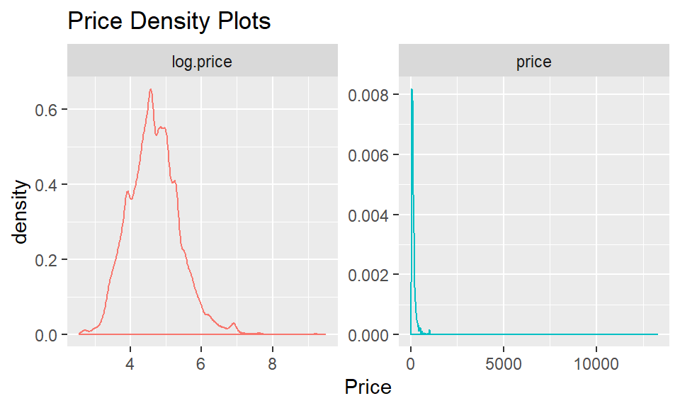

```r
airbnb %>%
  select(price) %>%
  mutate(log.price = log(price)) %>%
  pivot_longer(cols=price:log.price, names_to = "Type", values_to = "Price") %>%
  ggplot(aes(x=Price, group=Type, colour=Type)) +
  geom_density() +
  facet_wrap(~ Type, scales="free") +
  ggtitle("Price Density Plots") +
  theme(legend.position = "none")
```

The above plot tells us that the price data is heavily concentrated in the under $1000 price range and even moreso in the lower end of that bucket. Noting how dramatically right-skewed the distribution is, it will be better to model the log price instead as it offers a more normal shape.

## Neighbourhoods

Earlier on, we conjectured that neighbourhoods would be a defining characteristic of price as certain neighbourhoods are more desirable than others. Now, we can investigate the relationship between neighbourhood and price.

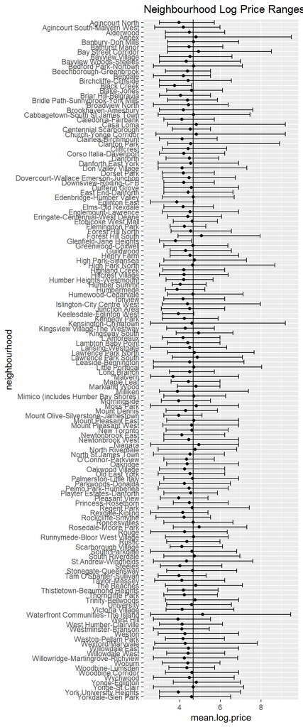

```r
airbnb %>%
  select(neighbourhood, price) %>%
  mutate(price = log(price)) %>%
  group_by(neighbourhood) %>%
  summarise(min.log.price = min(price), max.log.price = max(price),
            mean.log.price=mean(price)) %>%
  ggplot(aes(x=mean.log.price, y=neighbourhood)) +
  geom_point() +
  geom_vline(xintercept=mean(log(airbnb$price))) +
  geom_errorbarh(aes(xmin=min.log.price, xmax=max.log.price)) +
  scale_y_discrete(limits = rev(levels(airbnb$neighbourhood))) +
  ggtitle("Neighbourhood Log Price Ranges")
```

While perhaps a little busy, the above plot confirms our suspicions. We see that there are certain neighbourhoods with mean log price much higher than the average such as Waterfront Communities - The Island and some with much lower values such as Glenfield - Jane Heights. This suggests that neighbourhood could be a good option to structure a hierarchical model with.

## Host Information

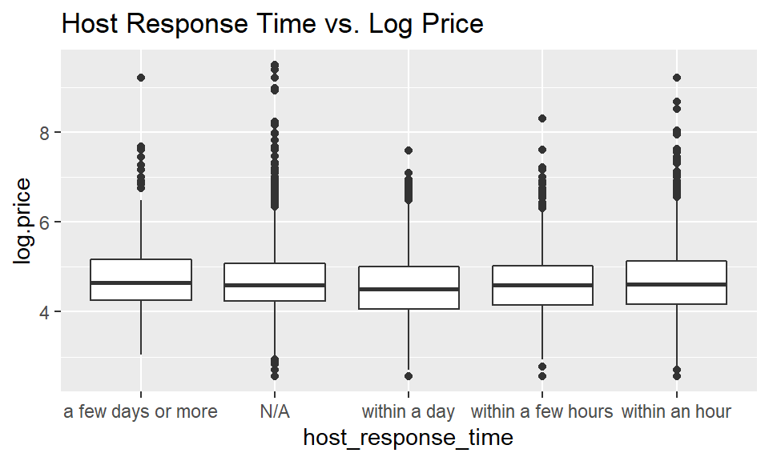

```r
airbnb <- airbnb %>% filter(!is.na(host_response_time)) %>% mutate(log.price = log(price))
airbnb %>%
  select(host_response_time, log.price) %>%
  ggplot(aes(x=host_response_time, y=log.price)) +
  geom_boxplot() +
  ggtitle("Host Response Time vs. Log Price")
```

The boxplots indicate that the distribution of prices by host response time have very similar central behaviour and that the differences lie in the tails. Notice that the “within an hour” category has a long upper tail suggesting that if fast response times are a proxy for a good host, good hosts charge more. The N/A category does have significant outliers in the tails which suggests a lack of insight into behaviour when response times are missing.

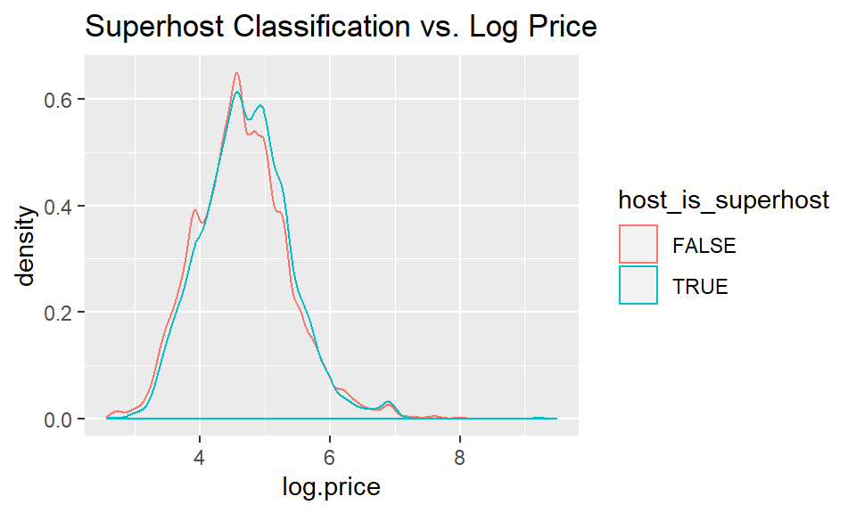

```r
airbnb %>% select(host_is_superhost, log.price) %>%
  ggplot(aes(x=log.price, colour=host_is_superhost)) +
  geom_density() +
  ggtitle("Superhost Classification vs. Log Price")
```

Overlaying the density of log price between the two superhost categories allows us to examine the differences more easily. In this case, the two categories have very similar density with the only major difference being the placement of secondary modes. This suggests that there really isn’t much information to be extracted from the superhost classification. For future modelling purposes, this variable has been converted from Boolean to 0-1.

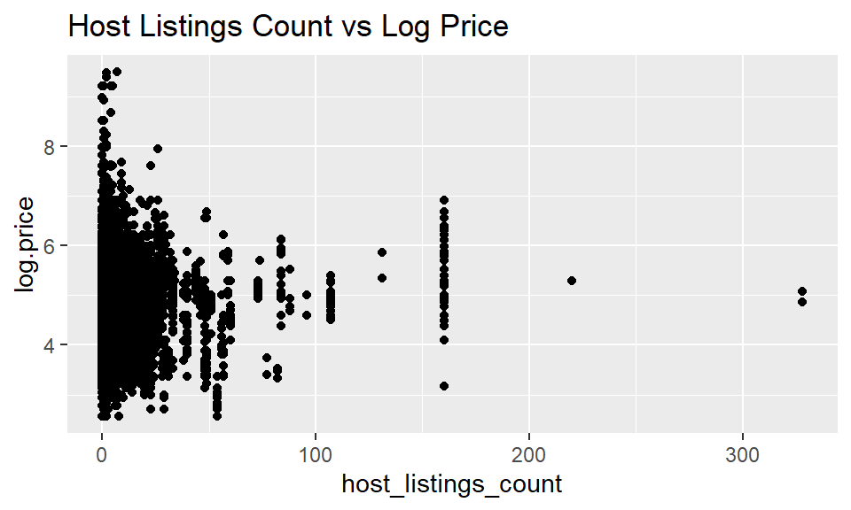

```r
airbnb %>% select(host_listings_count, log.price) %>%
  ggplot(aes(x=host_listings_count, y=log.price)) +
  geom_point() +
  ggtitle("Host Listings Count vs Log Price")
```

The host listings count does not appear to have a strong relationship with price. Note that the number of points corresponds to the number of listings not the number of hosts. Since a host with multiple listings can have multiple prices, they are represented in multiple points.

Finally, the host_since variable is an ordered factor. While the ordering is chronological, we want this to be continuous as opposed to categorical. We can transform these dates into number of days the listing has been up as of December 7, 2019 - the date the data was pulled. Then we can investigate the relationship with log price to see if there are patterns such as recent postings being more expensive as compared to old postings.

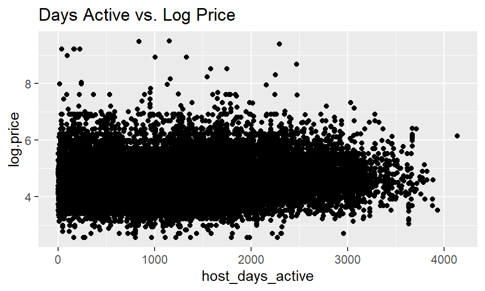

```r
airbnb <- airbnb %>%
  mutate(host_days_active = as.numeric(as.Date("2019-12-07"))-
           as.numeric(as.Date(host_since))) %>%
  select(host_id:host_since, host_days_active,
         host_response_time:price, log.price, number_of_reviews:review_scores_value)

airbnb %>% select(host_days_active, log.price) %>%
  ggplot(aes(x=host_days_active, y=log.price)) +
  geom_point() +
  ggtitle("Days Active vs. Log Price")
```

```r
cor(airbnb$host_days_active, airbnb$log.price)
```

```
## [1] 0.06401498
```

There does not appear to be a strong relationship between the days the host has been active and the log price. This is further confirmed by the low correlation value of 0.06.

In summary, the host information does not seem to have a strong relationship with price aside from possibly host response time acting as a proxy for host quality. However, there is no harm in using the variables in our models at first to extract any information they do contain.

## Room Types and Sizes

Similar to the neighbourhood variable, we expect the room types and sizes to directly impact the price - a larger listing should have a higher price all else equal. There are 34 observations that are missing either a bedrooms or bathrooms value. If we look at these listings, it isn’t clear what values should be imputed as there are a variety of room_types and accommodates values for each missing instance. Given the small number of missing points, we can safely remove these observations without dramatically altering the composition of the data. Then, comparing room types and sizes to log price, we can start with the room_type classification:

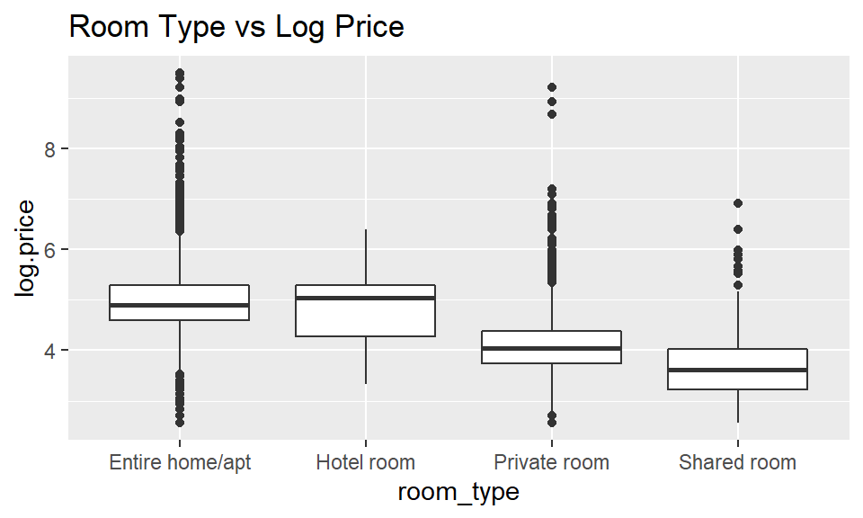

```r
airbnb %>% ggplot(aes(x=room_type, y=log.price)) +
  geom_boxplot() +
  ggtitle("Room Type vs Log Price")
```

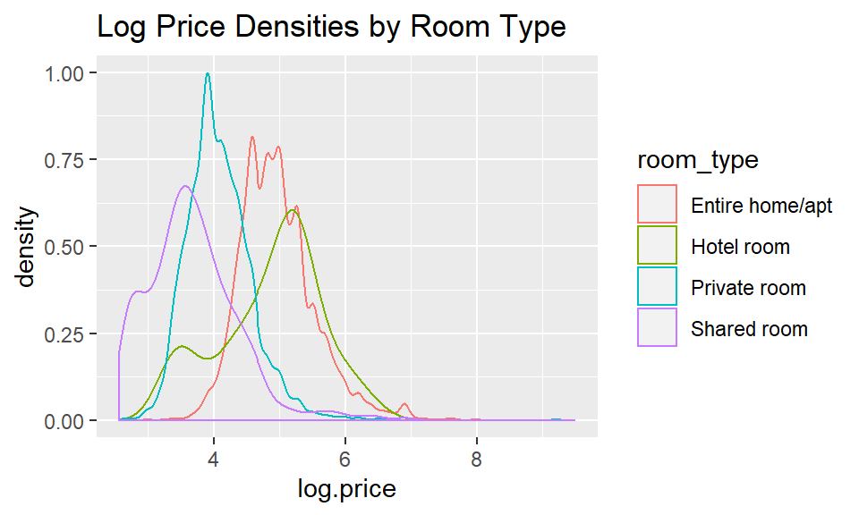

```r
airbnb %>% ggplot(aes(x=log.price, colour=room_type)) +
  geom_density() +
  ggtitle("Log Price Densities by Room Type")
```

The above plots illustrate that the room type has a substantial impact on price. The shared rooms are clearly the least expensive class of listing whereas entire home/apartment and hotel rooms tend to be on the higher end. Finally, the private rooms and entire home/apartment have the widest range with extremely high and extremely low values. They may be due to the wide range of possibilities that can be classified under these two categories. For example, both a studio apartment and a mansion could be in the entire home/apartment category. These differences are considered when we look at bedrooms, accommodates and bathrooms. Plotting each against log price,

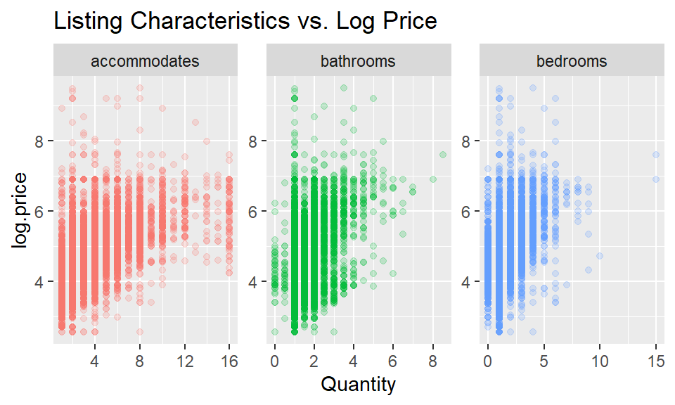

```r
airbnb %>% select(log.price, bathrooms, accommodates, bedrooms) %>%
  pivot_longer(-log.price, names_to="Category", values_to="Quantity") %>%
  ggplot(aes(x=Quantity, y=log.price, colour=Category)) +
  geom_point(alpha=0.2) +
  facet_wrap(~Category, scales="free") +
  theme(legend.position = "none") +
  ggtitle("Listing Characteristics vs. Log Price")
```

The above plots suggest that the price is positively correlated with each of accommodates, bathrooms, and bedrooms as expected. More concretely:

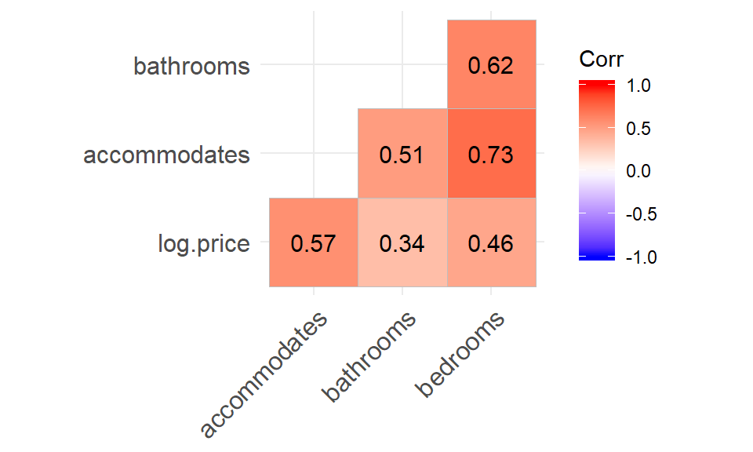

```r
corr1 <- cor(airbnb %>% select(log.price, accommodates, bathrooms, bedrooms))
ggcorrplot(corr1, type="lower", lab=TRUE)
```

We see that there is reasonably strong correlation between each of the features of interest. The log price is particularly strongly correlated with accommodates which suggests that there is a per head component of price.

## Review Scores

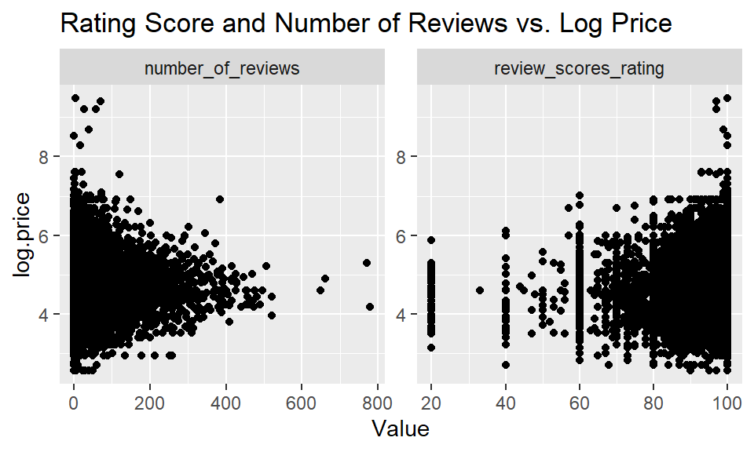

```r
airbnb %>% select(log.price, review_scores_rating, number_of_reviews) %>%
  pivot_longer(-log.price, names_to="Type", values_to="Value") %>%
  ggplot(aes(x=Value, y=log.price)) +
  geom_point() +
  facet_wrap(~ Type, scales="free") +
  ggtitle("Rating Score and Number of Reviews vs. Log Price")
```

The overall rating score versus log price is interesting. There seems to be a tendency to offer scores on multiples of 10 when the score is on the lower end. Also, all of the extremely high priced listings are in highest rating category. However, it is worth noting that the ratings with a high price and high score correspond to a small number of reviews. Part of the reason for this is that these expensive listings are far out of the price range of most guests and thus likely have fewer people staying in them. Considering the subcategories of the review score next:

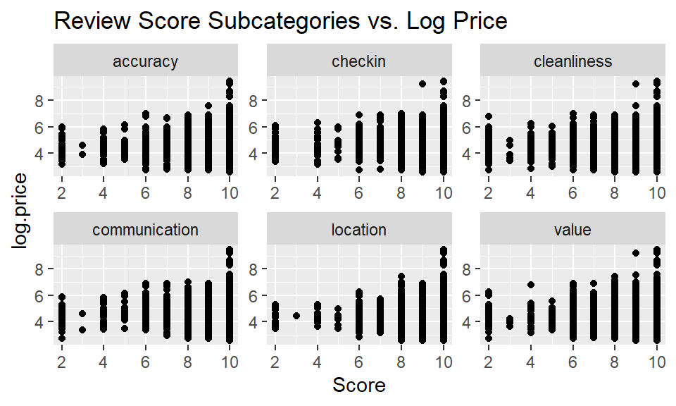

```r
airbnb %>% select(log.price, starts_with("review")) %>%
  select(-review_scores_rating) %>%
  pivot_longer(-log.price, names_to="Category", values_to="Score") %>%
  mutate(Category = gsub("review_scores_", "", Category)) %>%
  ggplot(aes(x=Score, y=log.price)) +
  geom_point() +
  facet_wrap(~ Category, ncol=3, scales="free") +
  ggtitle("Review Score Subcategories vs. Log Price")
```

Similar to the overall rating, the most expensive listings have high scores across all categories. However, that does not imply that less expensive categories exclusively receive low scores as seen by the wide range of prices at the top end of the review scores.

Finally, we can look at the correlation matrix between the review score categories:

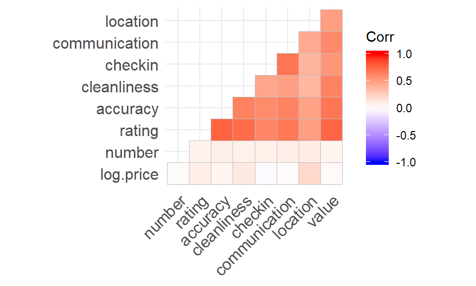

```r
corr2 <- cor(airbnb %>% select(log.price, contains("review")) %>%
               rename(location=review_scores_location,
                      communication=review_scores_communication,
                      checkin=review_scores_checkin,
                      cleanliness=review_scores_cleanliness,
                      accuracy=review_scores_accuracy,
                      rating=review_scores_rating,
                      number=number_of_reviews,
                      value=review_scores_value))
ggcorrplot(corr2, type="lower")
```

In summary, certain variable categories seem to influence log price more than others. Specifically, the listing characteristics seem to be more influential than the host characteristics. The room type, number of bathrooms, bedrooms, and occupants along with the neighbourhood seemed to have the greatest impact. Second, the review scores seemed to have a relationship with price as categories such a location had a positive correlation and large prices exclusively had high scores. The host categories did not seem to have a meaningful relationship with the log price aside from the number of outliers in the host response time.

# Modelling

Having explored the data and removed the difficult missing observations in reviews scores, host information and bed and bathrooms, we can begin to construct models for the purpose of predicting log price.

## Model 1 - Room Type Hierarchy with Fixed Effects

In order to run this model, we will need to one-hot encode the remaining categorical variables (host_response_time, neighbourhood), and convert room_type to room_type numbers. For the room_type point, as.factor followed by as.numeric will recode the values into numbers assigned alphabetically. Lastly, we will centre the numeric columns.

```r
print(levels(as.factor(airbnb$room_type)))
```

```
## [1] "Entire home/apt" "Hotel room"      "Private room"    "Shared room"
```

```r
abdata2 <- airbnb %>%
  select(-host_id, -host_since, -price) %>%
  mutate(room_type = as.numeric(as.factor(room_type)))  %>%
  mutate(temp = 1) %>%
  pivot_wider(names_from=neighbourhood, values_from=temp, values_fill=list(temp=0)) %>%
  mutate(temp = 1,
         host_response_time = ifelse(host_response_time=="N/A", "No Response",
                              ifelse(host_response_time=="within an hour", "Response_Hour",
                              ifelse(host_response_time=="within a day", "Response_Day",
                              ifelse(host_response_time=="within a few hours",
                                     "Response_Few_Hours", "Response_Few_Days"))))) %>%
  pivot_wider(names_from=host_response_time, values_from=temp, values_fill=list(temp=0)) %>%
  mutate(host_days_active = host_days_active - mean(host_days_active),
         host_listings_count = host_listings_count - mean(host_listings_count),
         bathrooms = bathrooms - mean(bathrooms),
         accommodates = accommodates - mean(accommodates),
         bedrooms = bedrooms - mean(bedrooms),
         number_of_reviews = number_of_reviews - mean(number_of_reviews),
         review_scores_rating = review_scores_rating - mean(review_scores_rating),
         review_scores_accuracy = review_scores_accuracy - mean(review_scores_accuracy),
         review_scores_cleanliness = review_scores_cleanliness -
           mean(review_scores_cleanliness),
         review_scores_checkin = review_scores_checkin - mean(review_scores_checkin),
         review_scores_communication = review_scores_communication -
           mean(review_scores_communication),
         review_scores_location = review_scores_location - mean(review_scores_location),
         review_scores_value = review_scores_value - mean(review_scores_value),)
```

For future reference, note that 1 corresponds to entire home/apartment, 2 is hotel room, 3 is private room, and 4 is shared room.

```r
sample2 <- abdata2 %>% sample_n(3000)
xmat2 <- as.matrix(sample2 %>% select(-room_type, -log.price))
dairbnbstan2 <- list(N = nrow(xmat2),
                     J = max(abdata2$room_type),
                     K = ncol(xmat2),
                     room = sample2$room_type,
                     xi = xmat2,
                     yi = sample2$log.price)

#abmod2 <- stan(data = dairbnbstan2,
#               file = "./airbnbmod2.stan",
#               iter = 2000,
#               seed = 123)
```

Now that the model has been completed (after a few hours) with 3000 samples and 2000 iterations, we can save the model so that we don’t need to rerun it each time we knit. In order to run the stan model, uncomment the stan commands and comment out the readRDS commands.

```r
#saveRDS(abmod2, "abfit2.rds")
```

#### Model 1 Diagnostics

Running the model is certainly a victory but we must ensure that it has converged and that the diagnostics look good. First, check the maximum Rhat value

```r
#Load in the model
abmod2 <- readRDS("abfit2.rds")
max(summary(abmod2)$summary[,c("Rhat")])
```

```
## [1] 1.127767
```

1.12 is certainly not ideal. Let’s investigate where this is coming from.

```r
summary(abmod2)$summary[summary(abmod2)$summary[,"Rhat"] >= 1.1,
                        c("mean", "se_mean", "n_eff", "Rhat")]
```

```
##                mean    se_mean    n_eff     Rhat
## beta[15] 0.17274461 0.01743822 39.23005 1.102506
## beta[16] 0.47786779 0.01693220 33.20288 1.127767
## beta[23] 0.41521837 0.01686414 38.17343 1.108018
## beta[24] 0.44869361 0.01704330 35.18316 1.118419
## beta[28] 0.14329839 0.01740913 38.03382 1.106207
## beta[29] 0.28680793 0.01686946 37.21353 1.111794
## beta[42] 0.40794360 0.01748025 37.14905 1.108627
## beta[45] 0.25284715 0.01704741 38.22020 1.109002
## beta[49] 0.09697618 0.01687873 38.80472 1.107294
## beta[52] 0.04862095 0.01691203 38.31878 1.108645
## beta[57] 0.31313614 0.01709482 38.62372 1.106235
```

The coefficients that seem to have not fully converged are all covariates corresponding to one-hot encoded neighbourhoods. Specifically, the 1.127767 corresponds to Waterfront Communities-The Island, a neighbourhood discussed earlier with a very wide range of listing prices. Let’s now focus on the group means, non-neighbourhood covariates, and $\mu$,$\sigma$ parameters.

```r
summary(abmod2)$summary[c(paste0("alpha[", 1:4, "]"),
                          paste0("beta[", 1:14, "]"), "mu", "sigma_a", "sigma_y"),
                        c("mean", "se_mean", "n_eff", "Rhat")]
```

```
##                   mean      se_mean     n_eff      Rhat
## alpha[1]  3.967105e+00 3.026007e-02  216.7610 1.0310233
## alpha[2]  4.073074e+00 3.052439e-02  227.3786 1.0291284
## alpha[3]  3.468707e+00 3.025012e-02  216.6171 1.0306961
## alpha[4]  3.293073e+00 2.997958e-02  223.9694 1.0302673
## beta[1]   1.055856e-05 1.694421e-07 3654.6906 1.0000452
## beta[2]   3.440864e-02 3.529557e-04 2913.9456 1.0001176
## beta[3]   3.226155e-03 8.293389e-06 4133.8671 0.9994698
## beta[4]   9.268698e-02 3.472863e-04 2646.1075 1.0007547
## beta[5]   8.117007e-02 1.117900e-04 2687.8479 0.9999165
## beta[6]   1.314220e-01 2.931114e-04 2290.7867 1.0014084
## beta[7]  -9.026744e-04 2.626506e-06 3632.3060 0.9996352
## beta[8]   5.131402e-03 2.800398e-05 4493.8722 0.9999833
## beta[9]  -1.967286e-02 3.136346e-04 2554.5823 1.0005133
## beta[10]  6.011630e-02 2.200378e-04 2795.5424 1.0005506
## beta[11]  2.704187e-03 3.189243e-04 2372.2735 0.9999385
## beta[12] -1.519373e-03 3.496976e-04 2294.9131 1.0007417
## beta[13]  4.723079e-02 2.830166e-04 2746.2211 0.9996268
## beta[14] -6.752501e-02 2.671318e-04 2738.1696 1.0001257
## mu        3.036913e+00 2.766376e-02  760.9360 1.0041609
## sigma_a   8.831661e-01 1.899337e-02  874.0795 1.0040308
## sigma_y   4.120392e-01 9.468381e-05 3201.1279 1.0006465
```

In the above, we can see that all of the variables of interest have converged with low Rhat values and reasonable effective sample sizes. Notice that the alpha values do have sizable differences suggesting that our intuition of the groups being materially different has merit.

Next, check the trace plots and density plots. We’ll start with the alphas:

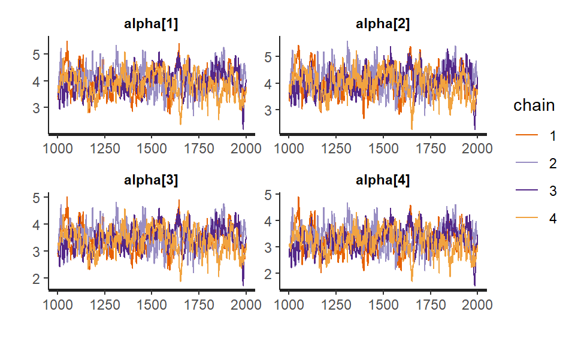

```r
pars = c(paste0("alpha[", 1:4, "]"))
traceplot(abmod2, pars=pars)
```

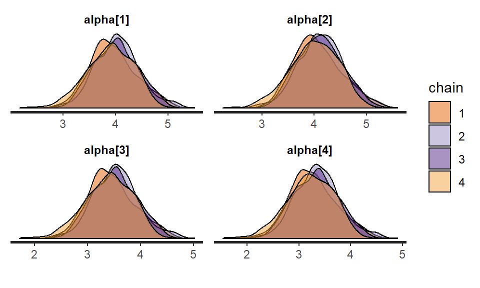

```r
stan_dens(abmod2, separate_chains=TRUE, pars=pars)
```

In the above plots, it would appear that the alpha values are mixing quite well. The chains do not appear to be diverging and exploring different regions and there does not seem to be a clear pattern in the trace plots.

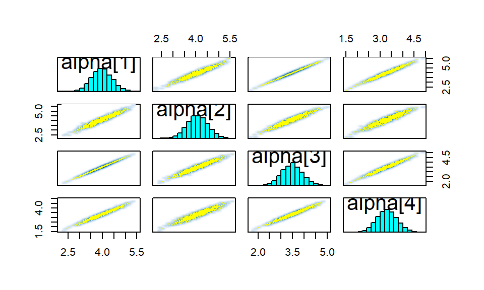

```r
pairs(abmod2, pars=pars)
```

Finally, the pairs and the density plots indicates that the densities of the alpha terms are roughly normal and highly correlated.

Moving to the $\mu$ and $\sigma$ parameters,

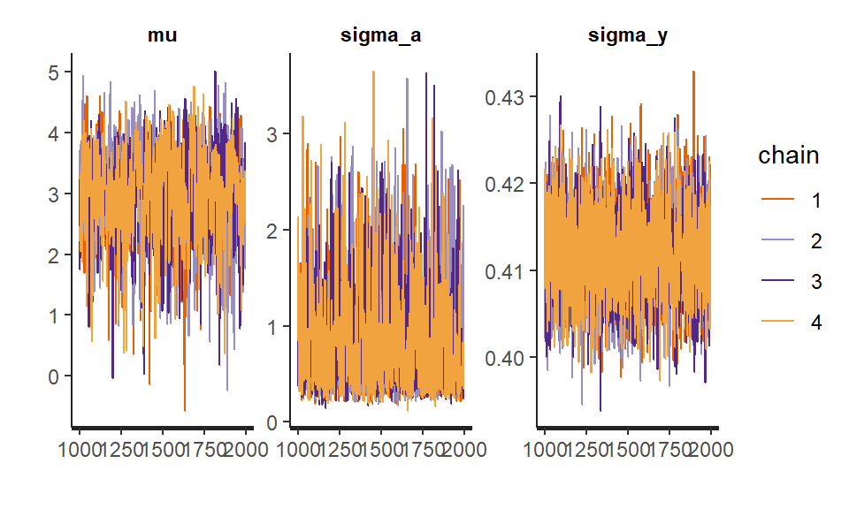

```r
pars = c("mu", "sigma_a", "sigma_y")
traceplot(abmod2, pars=pars)
```

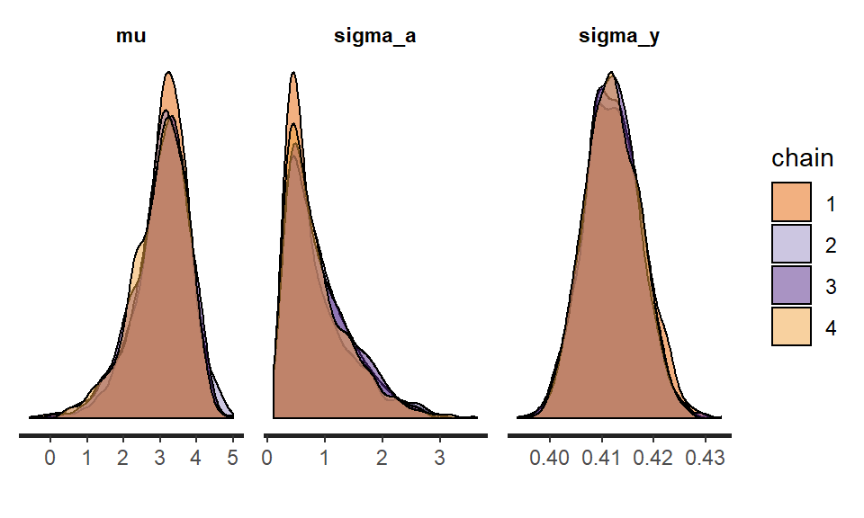

```r
stan_dens(abmod2, separate_chains=TRUE, pars=pars)
```

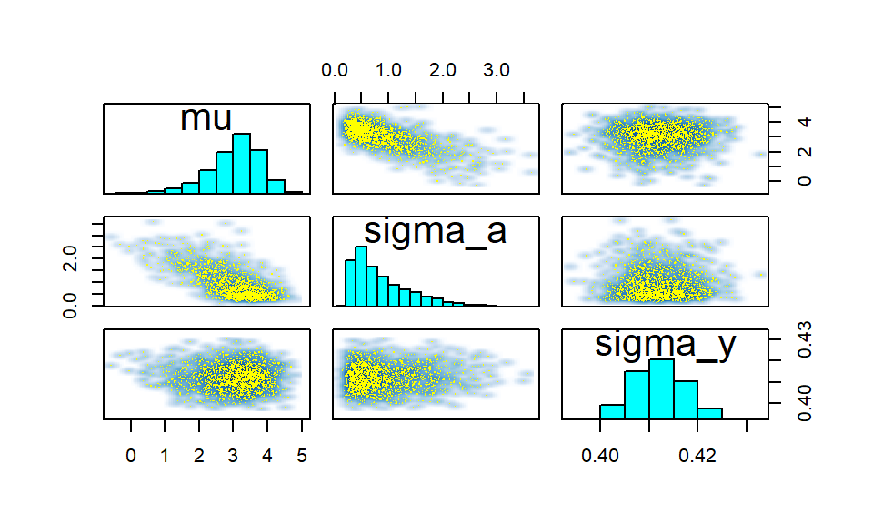

```r
pairs(abmod2, pars=pars)
```

Once again, the parameters do appear to be mixing quite well and the chains seems to be exploring the same region indicating convergence.

## Model 2 - Room Type Hierarchy with Mixed Effects

Using the same data as model 1, this time we can remove the accommodates, bathrooms, and bedrooms categories and put them in a separate matrix for input into stan. Once again with a sample of 3000 samples and 2000 iterations, the model does converge.

```r
sample3 <- abdata2 %>% sample_n(3000)
xmat3 <- as.matrix(sample3 %>% select(-room_type, -log.price, -accommodates,
                                      -bedrooms, -bathrooms))
zmat3 <- as.matrix(sample3 %>% select(accommodates, bathrooms, bedrooms))
dairbnbstan3 <- list(N = nrow(xmat3),
                     J = max(abdata2$room_type),
                     K = ncol(xmat3),
                     L = ncol(zmat3),
                     room = sample3$room_type,
                     xi = xmat3,
                     zi = zmat3,
                     yi = sample3$log.price)

#abmod3 <- stan(data = dairbnbstan3,
#               file = "./airbnbmod3.stan",
#               iter = 2000,
#               seed = 123)
```

```r
#saveRDS(abmod3, "abfit3.rds")
```

### Diagnostics

#### Discussion

Let’s now start with the Rhat values. First checking the maximum value:

```r
#Load in the model
abmod3 <- readRDS("abfit3.rds")
max(summary(abmod3)$summary[,"Rhat"])
```

```
## [1] NaN
```

```r
max(summary(abmod3)$summary[-161,"Rhat"])
```

```
## [1] 1.037472
```

The NaN seems rather strange. However, there is actually a very reasonable explanation for this. It occurs in the correlation matrix $\Omega$. Removing this line, we see that the maximum Rhat is 1.037, a much more pleasant value.

```r
summary(abmod3)$summary[c(paste0("Omega[1,",1:4,"]"),
                          paste0("Omega[2,",1:4,"]"),
                          paste0("Omega[3,",1:4,"]"),
                          paste0("Omega[4,",1:4,"]")),
                        c("mean", "se_mean", "n_eff", "Rhat")]
```

```
##                    mean      se_mean    n_eff      Rhat
## Omega[1,1]  1.000000000          NaN      NaN       NaN
## Omega[1,2]  0.028381932 7.706500e-03 2653.390 1.0007273
## Omega[1,3] -0.033594427 7.882963e-03 2319.844 1.0013936
## Omega[1,4]  0.030028035 8.368553e-03 2296.898 1.0010155
## Omega[2,1]  0.028381932 7.706500e-03 2653.390 1.0007273
## Omega[2,2]  1.000000000 1.441338e-18 3979.205 0.9989995
## Omega[2,3] -0.128573476 7.607960e-03 2477.702 1.0017679
## Omega[2,4] -0.050103275 6.899487e-03 2968.479 1.0006087
## Omega[3,1] -0.033594427 7.882963e-03 2319.844 1.0013936
## Omega[3,2] -0.128573476 7.607960e-03 2477.702 1.0017679
## Omega[3,3]  1.000000000 1.774042e-18 2697.150 0.9989995
## Omega[3,4] -0.003655796 8.579475e-03 2029.221 1.0012262
## Omega[4,1]  0.030028035 8.368553e-03 2296.898 1.0010155
## Omega[4,2] -0.050103275 6.899487e-03 2968.479 1.0006087
## Omega[4,3] -0.003655796 8.579475e-03 2029.221 1.0012262
## Omega[4,4]  1.000000000 1.691040e-18 3670.104 0.9989995
```

```r
summary(abmod3)$summary[c(paste0("ag[1,",1:4,"]"),
                          paste0("ag[2,",1:4,"]"),
                          paste0("ag[3,",1:4,"]"),
                          paste0("ag[4,",1:4,"]")),
                        c("mean", "se_mean", "n_eff", "Rhat")]
```

```
##                mean      se_mean     n_eff      Rhat
## ag[1,1]  4.29743940 0.0286085534  279.9376 1.0091724
## ag[1,2]  0.05929255 0.0001550039 2108.2260 1.0009916
## ag[1,3]  0.14684113 0.0004976324 2465.1823 0.9997156
## ag[1,4]  0.13812541 0.0003952865 1775.1112 1.0015285
## ag[2,1]  4.67525979 0.0296405768  304.8940 1.0077139
## ag[2,2]  0.14352514 0.0030023888 1051.3606 1.0041853
## ag[2,3] -0.77787404 0.0398384250  475.7251 1.0051276
## ag[2,4]  0.16319084 0.0071919922  778.6126 1.0022261
## ag[3,1]  3.78603484 0.0286603600  279.2262 1.0092028
## ag[3,2]  0.10637217 0.0003782433 1688.8947 1.0009360
## ag[3,3] -0.03566100 0.0006270280 2796.8090 0.9997298
## ag[3,4]  0.06947840 0.0013253112 1108.1132 1.0030365
## ag[4,1]  3.16577668 0.0300469812  283.8745 1.0087145
## ag[4,2]  0.05462881 0.0011513317 1962.7018 1.0008242
## ag[4,3] -0.08208863 0.0030536353 2650.5707 1.0011734
## ag[4,4]  0.12390170 0.0119762767  907.9849 1.0019539
```

Looking at the output for the $\alpha$ and $\gamma$ terms, the effective sample size is always greater than 200 and the Rhat is essentially 1. Given these are the parameters of the most complex part of our model structure, this is a good sign that the model converged

#### Trace Plots

##### Entire Home/Apartment

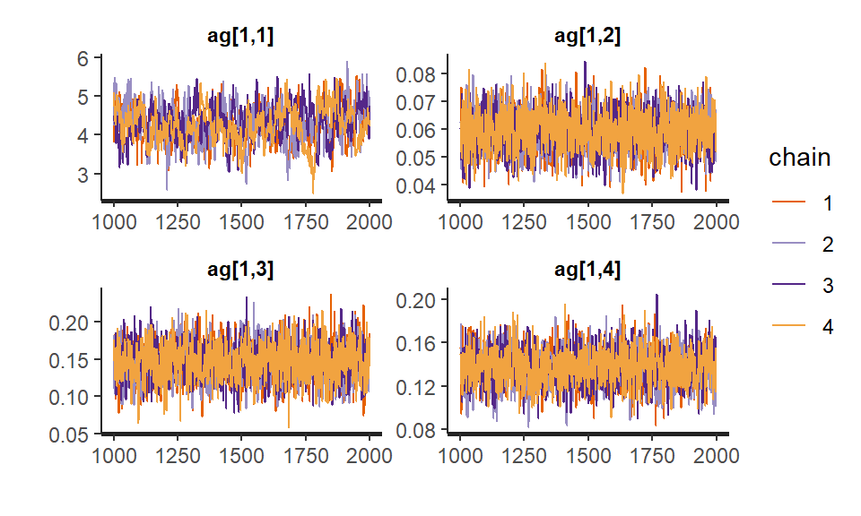

```r
pars = c(paste0("ag[1,", 1:4, "]"))
traceplot(abmod3, pars=pars)
```

##### Hotel Room

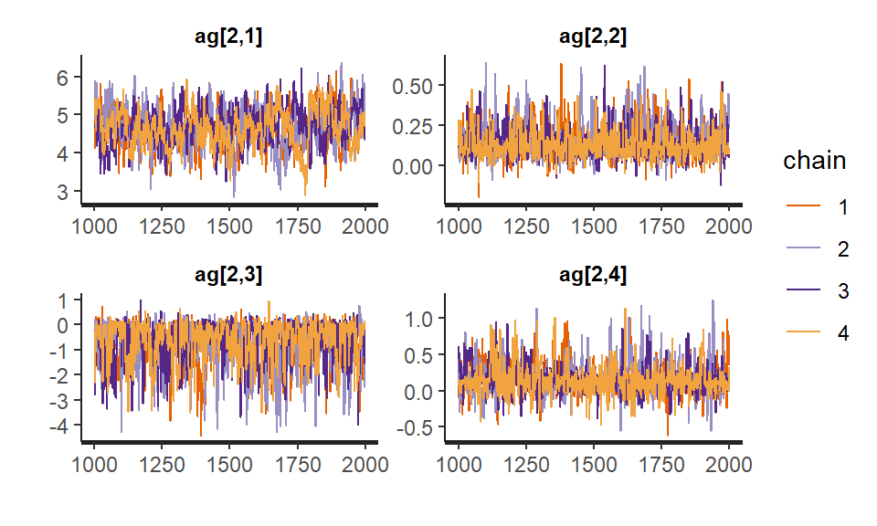

```r
pars = c(paste0("ag[2,", 1:4, "]"))
traceplot(abmod3, pars=pars)
```

##### Private Room

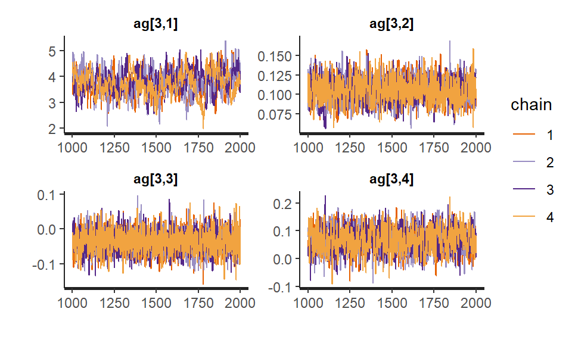

```r
pars = c(paste0("ag[3,", 1:4, "]"))
traceplot(abmod3, pars=pars)
```

##### Shared Room

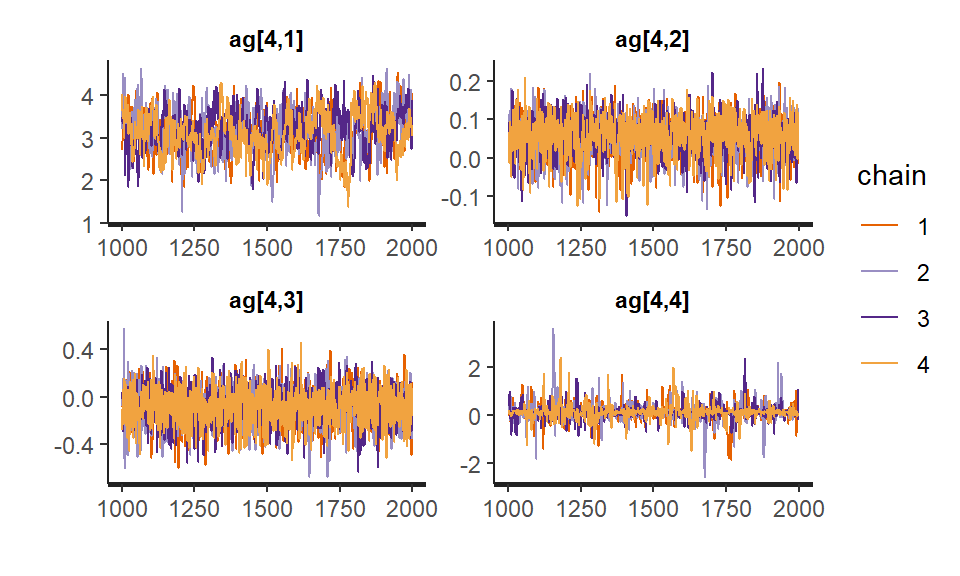

```r
pars = c(paste0("ag[4,", 1:4, "]"))
traceplot(abmod3, pars=pars)
```

In the above trace plots for alpha and gamma terms, it seems that each variable is mixing quite well. It does appear that the alpha terms (top left) are mixing slightly less well though there does not appear to be any overall trend or suggestion that the chain is still attempting to move towards stationarity.

#### Density and Pairs Plots

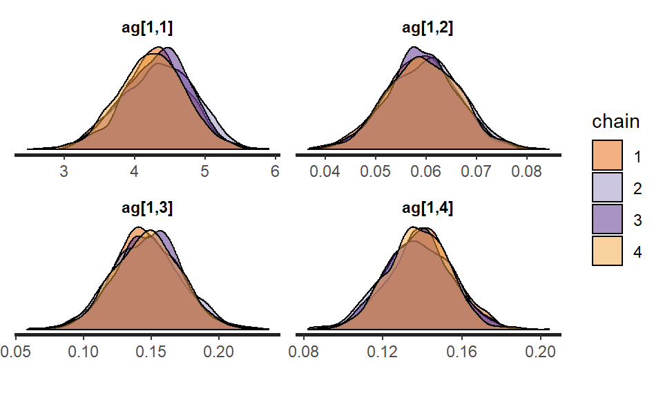

```r
pars = c(paste0("ag[1,", 1:4, "]"))
stan_dens(abmod3, separate_chains=TRUE, pars=pars)
```

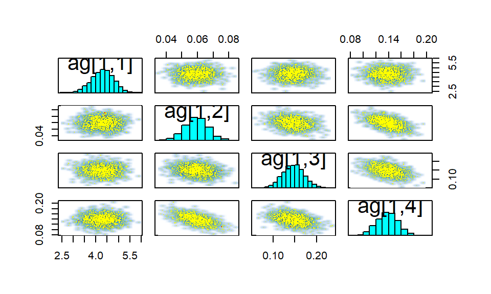

```r
pairs(abmod3, pars=pars)
```

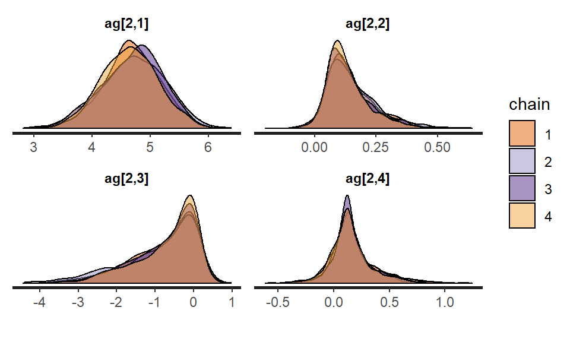

```r
pars = c(paste0("ag[2,", 1:4, "]"))
stan_dens(abmod3, separate_chains=TRUE, pars=pars)
```

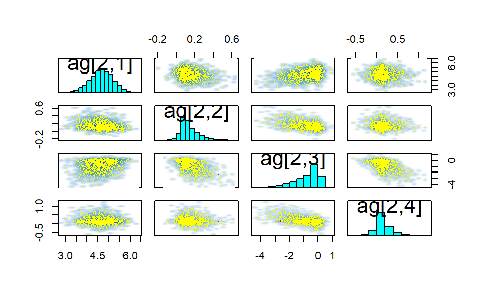

```r
pairs(abmod3, pars=pars)
```

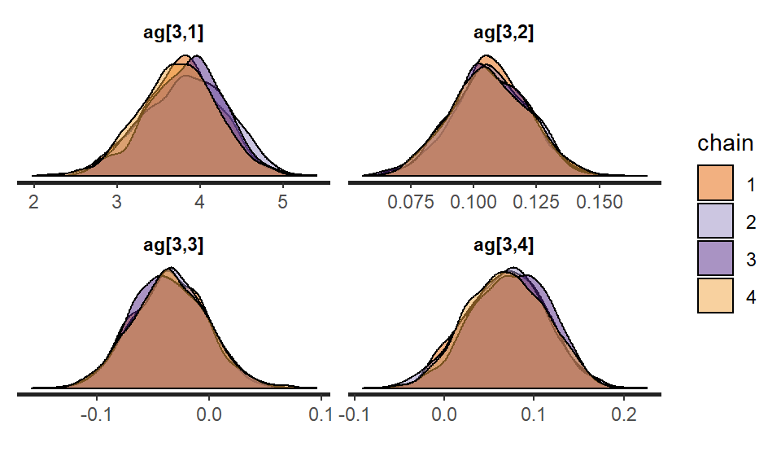

```r
pars = c(paste0("ag[3,", 1:4, "]"))
stan_dens(abmod3, separate_chains=TRUE, pars=pars)
```

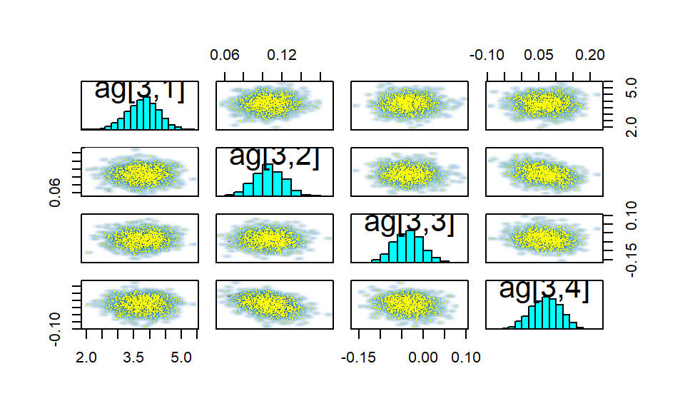

```r
pairs(abmod3, pars=pars)
```

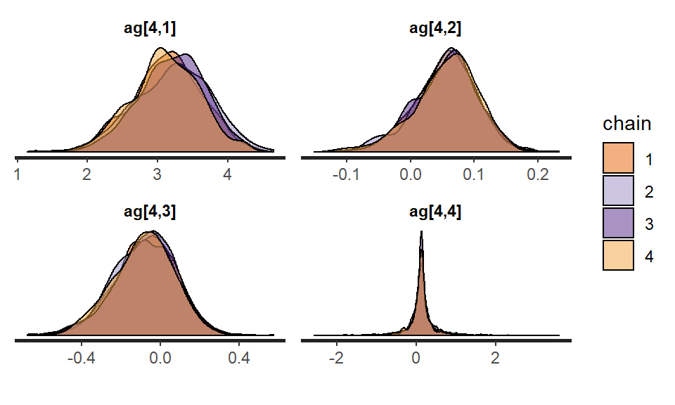

```r
pars = c(paste0("ag[4,", 1:4, "]"))
stan_dens(abmod3, separate_chains=TRUE, pars=pars)
```

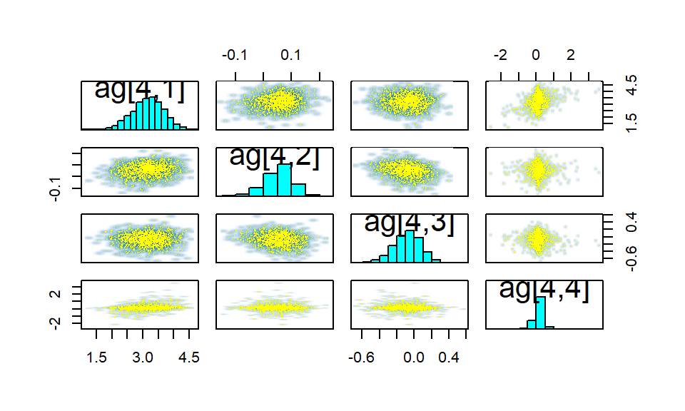

```r
pairs(abmod3, pars=pars)
```

Looking at the density plots now, it would appear that the chains have all converged to the same distributions. The pairs plots further our confidence that Model 3 has converged.

## Part c

To compare the models, we can use LOO-CV.

```r
loglik2 <- as.matrix(abmod2, pars="log_lik")
loglik3 <- as.matrix(abmod3, pars="log_lik")

loo2 <- loo(loglik2, save_psis=TRUE)
loo3 <- loo(loglik3, save_psis=TRUE)
```

```r
loo_compare(loo2,loo3)
```

```
##        elpd_diff se_diff
## model2   0.0       0.0
## model1 -73.3     100.1
```